# Rays R&D

Ronald Garcia

2025-03-06

In this project, I analyzed batted ball data to estimate the “true” exit velocity (speed-off-bat) of hitters. Two separate measurement systems (System A and System B) provide exit velocity and vertical angle (launch angle) values, but not all data points are recorded for both systems. Additionally, I am told that it is suspected that System A is more accurate than System B.

My goals in this project are as listed: 1. Compare and evaluate the differences between the two systems. 2. Handle all the missing data using regression imputation. 3. Estimate a “true” exit velocity for each batted ball. 4. Project each batter’s expected exit velocity for the following season.

We begin by loading the dataset and inspecting its structure.

```r
# Loading the batted ball csv file
battedball <- read_csv("~/Desktop/Baseball/battedBallData.csv")
head(battedball)
```

```
## # A tibble: 6 × 7
##   batter pitcher hittype     speed_A vangle_A speed_B vangle_B
##    <dbl>   <dbl> <chr>         <dbl>    <dbl>   <dbl>    <dbl>
## 1    393     405 ground_ball   111.      4.19   104.      3.16
## 2    366     405 ground_ball    60.1   -54.7     28.1   -28.3
## 3    448     518 line_drive    103.     11.8     97.8    11.7
## 4    140     518 fly_ball       62.0    33.5     59.4    32.8
## 5    521     518 line_drive    117.     22.7    111.     23.2
## 6    401     518 ground_ball   106.    -10.5     78.5    -7.47
```

```r
# checking data
str(battedball)
```

```
## spc_tbl_ [73,375 × 7] (S3: spec_tbl_df/tbl_df/tbl/data.frame)
##  $ batter  : num [1:73375] 393 366 448 140 521 401 184 88 652 672 ...
##  $ pitcher : num [1:73375] 405 405 518 518 518 518 405 405 405 405 ...
##  $ hittype : chr [1:73375] "ground_ball" "ground_ball" "line_drive" "fly_ball" ...
##  $ speed_A : num [1:73375] 111 60.1 102.8 62 116.7 ...
##  $ vangle_A: num [1:73375] 4.19 -54.65 11.75 33.49 22.7 ...
##  $ speed_B : num [1:73375] 103.8 28.1 97.8 59.4 111 ...
##  $ vangle_B: num [1:73375] 3.16 -28.32 11.66 32.8 23.16 ...
##  - attr(*, "spec")=
##   .. cols(
##   ..   batter = col_double(),
##   ..   pitcher = col_double(),
##   ..   hittype = col_character(),
##   ..   speed_A = col_double(),
##   ..   vangle_A = col_double(),
##   ..   speed_B = col_double(),
##   ..   vangle_B = col_double()
##   .. )
##  - attr(*, "problems")=<externalptr>
```

```r
summary(battedball)
```

```
##      batter         pitcher      hittype             speed_A
##  Min.   :  1.0   Min.   :  1   Length:73375       Min.   : 26.46
##  1st Qu.:170.0   1st Qu.:121   Class :character   1st Qu.: 80.36
##  Median :341.0   Median :283   Mode  :character   Median : 90.64
##  Mean   :365.1   Mean   :290                      Mean   : 88.42
##  3rd Qu.:550.0   3rd Qu.:447                      3rd Qu.: 98.32
##  Max.   :816.0   Max.   :645                      Max.   :121.85
##                                                   NA's   :7572
##     vangle_A          speed_B           vangle_B
##  Min.   :-91.899   Min.   :  5.152   Min.   :-85.091
##  1st Qu.: -5.559   1st Qu.: 66.074   1st Qu.: -4.635
##  Median : 11.005   Median : 81.887   Median : 10.546
##  Mean   : 10.854   Mean   : 77.748   Mean   : 13.094
##  3rd Qu.: 27.405   3rd Qu.: 92.327   3rd Qu.: 28.881
##  Max.   : 78.461   Max.   :114.403   Max.   : 90.901
##  NA's   :7572      NA's   :1402      NA's   :1402
```

## The dataset contains columns for speed_A, speed_B, vangle_A, vangle_B, hittype, and batter/pitcher identifiers. Many values are missing (NA), making data imputation necessary for me continue on the task.

I investigate the differences between System A and System B and visualize them through histograms.

```r
#  differences between system A and B
battedball <- battedball %>%
  mutate(speed_diff = speed_A - speed_B,
         vangle_diff = vangle_A - vangle_B)

# summarize differences
summary(battedball$speed_diff)
```

```
##    Min. 1st Qu.  Median    Mean 3rd Qu.    Max.    NA's
## -58.415   3.331   4.182   8.652   6.431  76.960    8432
```

```r
summary(battedball$vangle_diff)
```

```
##     Min.  1st Qu.   Median     Mean  3rd Qu.     Max.     NA's
## -126.844   -0.909   -0.041   -1.630    0.752   72.238     8432
```

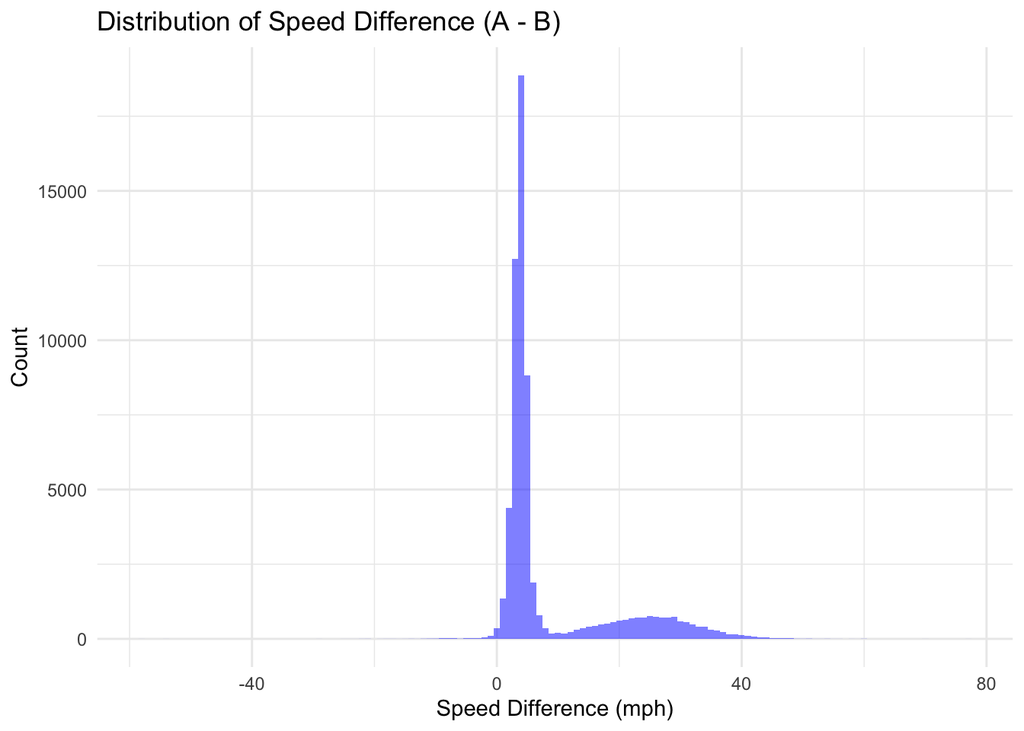

```r
# plot distribution of differences
ggplot(battedball, aes(x = speed_diff)) +
  geom_histogram(binwidth = 1, fill = "blue", alpha = 0.5) +
  labs(title = "Distribution of Speed Difference (A - B)",
       x = "Speed Difference (mph)", y = "Count") +
  theme_minimal()
```

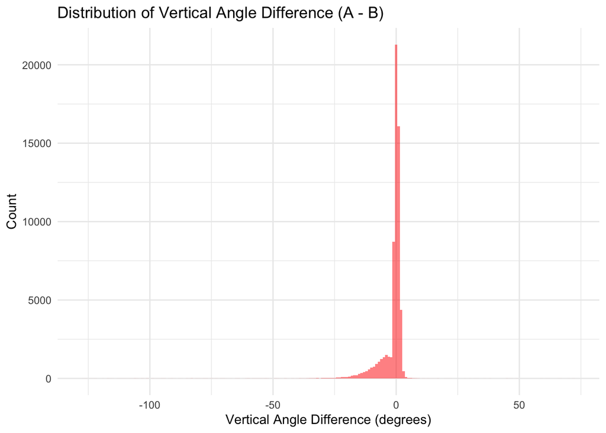

```r
ggplot(battedball, aes(x = vangle_diff)) +
  geom_histogram(binwidth = 1, fill = "red", alpha = 0.5) +
  labs(title = "Distribution of Vertical Angle Difference (A - B)",
       x = "Vertical Angle Difference (degrees)", y = "Count") +
  theme_minimal()
```

The histograms indicate that System B is more often underestimating exit velocity compared to System A, it also shows there is variability in the launch angle measurements. – I now calculated the correlation between the two systems.

```r
cor_speed <- cor(battedball$speed_A, battedball$speed_B, use = "complete.obs")
cor_vangle <- cor(battedball$vangle_A, battedball$vangle_B, use = "complete.obs")

print(paste("Correlation for Speed:", round(cor_speed, 3)))
```

```
## [1] "Correlation for Speed: 0.817"
```

```r
print(paste("Correlation for Vertical Angle:", round(cor_vangle, 3)))
```

```
## [1] "Correlation for Vertical Angle: 0.967"
```

## The results show that System A and System B are positively correlated, but not perfectly, suggesting the presence of a bias or measurement inconsistencies.

I used linear regression imputation to then estimate the missing values (NA’s) in both speed and vangle columns.

```r
# Imputing speed_A using speed_B
speed_model <-
  lm(speed_A ~ speed_B, data = battedball, na.action = na.exclude)

battedball$speed_A[is.na(battedball$speed_A)] <- predict(speed_model, newdata = battedball[is.na(battedball$speed_A),])

# Imputing speed_B using speed_A
speed_model_rev <-
  lm(speed_B ~ speed_A, data = battedball, na.action = na.exclude)

battedball$speed_B[is.na(battedball$speed_B)] <- predict(speed_model_rev, newdata = battedball[is.na(battedball$speed_B),])

# Imputing vangle_A using vangle_B
vangle_model <-
  lm(vangle_A ~ vangle_B, data = battedball, na.action = na.exclude)

battedball$vangle_A[is.na(battedball$vangle_A)] <- predict(vangle_model, newdata = battedball[is.na(battedball$vangle_A),])

# Imputing vangle_B using vangle_A
vangle_model_rev <-
  lm(vangle_B ~ vangle_A, data = battedball, na.action = na.exclude)

battedball$vangle_B[is.na(battedball$vangle_B)] <- predict(vangle_model_rev, newdata = battedball[is.na(battedball$vangle_B),])
```

Since system A is more accurate, I now create a weighted formula to create a estimated true speed.

```r
# Assume System A is more accurate and weight it more heavily because the prompt said it is much more accurate
battedball <- battedball %>%
  mutate(true_speed = case_when(
    !is.na(speed_A) & !is.na(speed_B) ~ (0.7 * speed_A + 0.3 * speed_B),  # The created weighted average
    is.na(speed_A) & !is.na(speed_B) ~ speed_B * (mean(speed_A, na.rm = TRUE) / mean(speed_B, na.rm = TRUE)), # Adjust speed_B
    !is.na(speed_A) & is.na(speed_B) ~ speed_A,  # Using speed_A if available
    TRUE ~ NA_real_
  ))

# dataset now has new true_speed column
head(battedball)
```

```
## # A tibble: 6 × 10
##   batter pitcher hittype     speed_A vangle_A speed_B vangle_B speed_diff
##    <dbl>   <dbl> <chr>         <dbl>    <dbl>   <dbl>    <dbl>      <dbl>
## 1    393     405 ground_ball   111.      4.19   104.      3.16       7.14
## 2    366     405 ground_ball    60.1   -54.7     28.1   -28.3       32.0
## 3    448     518 line_drive    103.     11.8     97.8    11.7        4.91
## 4    140     518 fly_ball       62.0    33.5     59.4    32.8        2.56
## 5    521     518 line_drive    117.     22.7    111.     23.2        5.68
## 6    401     518 ground_ball   106.    -10.5     78.5    -7.47      27.5
## # ℹ 2 more variables: vangle_diff <dbl>, true_speed <dbl>
```

I now computed each batters expected exit velocity for their following season. Using both a table for all players in the data given, and a table using a hand selected qualification number of a 100 batted ball minimum to have a chart with a ‘qualified’ sample size.

```r
# computed batter level averages
batter_speeds <- battedball %>%
  group_by(batter) %>%
  summarize(avg_true_speed = mean(true_speed, na.rm = TRUE),
            avg_vangle = mean(vangle_A, na.rm = TRUE),
            num_balls = n()) %>%
  arrange(desc(avg_true_speed))

# display the table
true_batters <- kable(batter_speeds, caption = "Projected True Speed Off Bat for Following Season")

qualified_batter_speeds <- filter(batter_speeds, num_balls >= 100)

qualified_true_batters <- kable(qualified_batter_speeds, caption = "Projected True Speed Off Bat for Following Season (min. 100 BBE)")

true_batters
```

Projected True Speed Off Bat for Following Season

| batter | avg_true_speed | avg_vangle | num_balls |
| --- | --- | --- | --- |
| 697 | 110.45330 | 9.4836603 | 1 |
| 737 | 104.20566 | 49.8641938 | 1 |
| 236 | 103.22417 | -0.8104630 | 3 |
| 225 | 101.21070 | 10.7933912 | 1 |
| 359 | 100.28435 | 21.7375074 | 1 |
| 517 | 98.81836 | 0.4802657 | 1 |
| 535 | 98.74188 | 0.3238855 | 2 |
| 256 | 98.29771 | -4.2867097 | 1 |
| 37 | 97.69740 | 28.0039041 | 4 |
| 424 | 97.56551 | 9.3776080 | 1 |
| 698 | 97.08684 | 7.7138131 | 1 |
| 340 | 96.71500 | 31.2674708 | 2 |
| 521 | 95.94804 | 15.7982105 | 9 |
| 765 | 95.92330 | 10.2153128 | 13 |
| 803 | 95.91347 | 11.8360121 | 7 |
| 761 | 95.85332 | 13.8185524 | 5 |
| 668 | 95.84750 | 15.9599567 | 12 |
| 420 | 95.62238 | 18.4636877 | 1 |
| 226 | 94.16050 | 20.8697640 | 1 |
| 520 | 93.03287 | 5.3981286 | 17 |
| 257 | 92.92198 | 20.0786853 | 41 |
| 694 | 92.23606 | 16.1978917 | 3 |
| 322 | 92.01172 | 2.1004342 | 1 |
| 179 | 91.60818 | -0.9204566 | 3 |
| 493 | 91.53027 | 11.8948776 | 91 |
| 418 | 91.47932 | 18.0503414 | 1 |
| 441 | 91.37330 | 12.4567012 | 1 |
| 649 | 91.30271 | -3.3818098 | 5 |
| 677 | 91.22971 | 19.3150891 | 281 |
| 21 | 91.10129 | 20.4127132 | 14 |

[output cut: 786 more lines]

```r
qualified_true_batters
```

Projected True Speed Off Bat for Following Season (min. 100 BBE)

| batter | avg_true_speed | avg_vangle | num_balls |
| --- | --- | --- | --- |
| 677 | 91.22971 | 19.3150891 | 281 |
| 325 | 90.84417 | 12.0860053 | 125 |
| 105 | 90.68217 | 14.7607781 | 303 |
| 88 | 90.65173 | 15.8397508 | 259 |
| 342 | 90.50996 | 10.4248923 | 300 |
| 47 | 90.44711 | 9.4379772 | 380 |
| 301 | 90.37489 | 13.7190737 | 312 |
| 660 | 90.28477 | 14.5284556 | 145 |
| 65 | 90.22553 | 12.1634783 | 163 |
| 407 | 90.20058 | 7.6741452 | 149 |
| 728 | 90.16220 | 18.7995841 | 134 |
| 534 | 90.16191 | 12.5500991 | 325 |
| 369 | 90.11914 | 12.2718814 | 123 |
| 243 | 89.88663 | 14.5410968 | 204 |
| 415 | 89.79048 | 12.7205450 | 208 |
| 479 | 89.68141 | 19.4595641 | 195 |
| 574 | 89.60575 | 20.9820150 | 175 |
| 434 | 89.56353 | 8.9509018 | 137 |
| 754 | 89.40548 | 15.9019567 | 105 |
| 603 | 89.28847 | 17.5147886 | 184 |
| 155 | 89.22777 | 12.1582680 | 129 |
| 319 | 88.96236 | 18.3930810 | 151 |
| 312 | 88.95129 | 11.4767003 | 105 |
| 218 | 88.71210 | 17.4783355 | 233 |
| 384 | 88.62219 | 19.6344522 | 253 |
| 94 | 88.49885 | 5.1222877 | 110 |
| 553 | 88.40590 | 14.0845755 | 125 |
| 684 | 88.37413 | 6.8182881 | 141 |
| 247 | 88.36977 | 22.0071377 | 171 |
| 721 | 88.34812 | 14.0251233 | 186 |

[output cut: 260 more lines]

I then created an extra plot to find interesting information like the hit type distribution for the new “true_speed”.

```r
# Average true speed by hit type
hittype_speeds <- battedball %>%
  group_by(hittype) %>%
  summarize(avg_true_speed = mean(true_speed, na.rm = TRUE),
            avg_vangle = mean(vangle_A, na.rm = TRUE))

# Display table
kable(hittype_speeds, caption = "True Speed-Off-Bat by Hit Type")
```

True Speed-Off-Bat by Hit Type

| hittype | avg_true_speed | avg_vangle |
| --- | --- | --- |
| U | 81.72498 | -1.28982 |
| fly_ball | 88.93924 | 35.46772 |
| ground_ball | 79.10139 | -10.95710 |
| line_drive | 91.59167 | 15.80576 |
| popup | 76.35987 | 64.03530 |

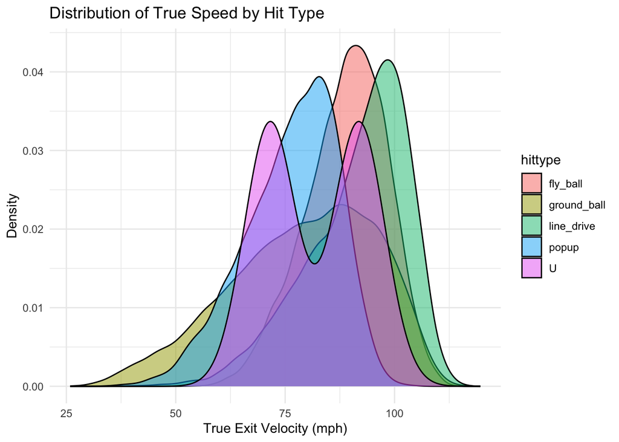

```r
# Plot hit type distributions
ggplot(battedball, aes(x = true_speed, fill = hittype)) +
  geom_density(alpha = 0.5) +
  labs(title = "Distribution of True Speed by Hit Type",
       x = "True Exit Velocity (mph)", y = "Density") +
  theme_minimal()
```

In this analysis, I examined batted ball data to estimate the true exit velocity of hitters while accounting for differences between two measurement systems (System A and System B).

The findings reveal that: 1. System A is more reliable and generally reports higher exit velocities than System B. 2. System B systematically underestimates exit velocity, but the two systems are still positively correlated. 3. Missing data was effectively handled using regression imputation, ensuring that incomplete records did not distort our analysis. 4. A weighted average approach (70% System A, 30% System B) was used to estimate “true” exit velocity for each batted ball. 5. Future performance projections were generated for each batter, allowing us to estimate expected exit velocity in the next season. 6. Additionally, we explored how exit velocity varies by hit type, finding that line drives and fly balls typically have higher exit velocities, whereas ground balls and popups tend to be hit with lower speeds.

Overall, our approach enables a more accurate assessment of hitter performance by correcting for biases between measurement systems and leveraging imputation techniques to maximize the available data.